# COVID_19 Report

Monone Damilola

2024-04-10

# Introduction

This report provides an analysis of COVID-19 data, focusing on different continents’ population, total cases, and death cases. It is a personal project to practice R studio, in which the data set used is an open data from COVID_19 website.

## Data cleaning and manipulation

```r
cleaned_data <- na.omit(covid_data)
print(cleaned_data)
```

```
## # A tibble: 69,468 × 7
##    iso_code continent location    date                population total_cases
##    <chr>    <chr>     <chr>       <dttm>                   <dbl>       <dbl>
##  1 AFG      Asia      Afghanistan 2020-03-22 00:00:00   38928341          34
##  2 AFG      Asia      Afghanistan 2020-03-23 00:00:00   38928341          41
##  3 AFG      Asia      Afghanistan 2020-03-24 00:00:00   38928341          43
##  4 AFG      Asia      Afghanistan 2020-03-25 00:00:00   38928341          76
##  5 AFG      Asia      Afghanistan 2020-03-26 00:00:00   38928341          80
##  6 AFG      Asia      Afghanistan 2020-03-27 00:00:00   38928341          91
##  7 AFG      Asia      Afghanistan 2020-03-28 00:00:00   38928341         107
##  8 AFG      Asia      Afghanistan 2020-03-29 00:00:00   38928341         118
##  9 AFG      Asia      Afghanistan 2020-03-30 00:00:00   38928341         146
## 10 AFG      Asia      Afghanistan 2020-03-31 00:00:00   38928341         175
## # ℹ 69,458 more rows
## # ℹ 1 more variable: total_deaths <dbl>
```

# Overview of the Dataset

```r
print(summary)
```

[output not shown]

# Calculate total population, total cases and death cases per continent

```r
population_table <- cleaned_data %>%
  group_by(continent) %>%
  summarise(total_population = sum(population))

deaths_table <- cleaned_data %>%
  group_by(continent) %>%
  summarise(total_deaths = sum(total_deaths))

cases_table <- cleaned_data %>%
  group_by(continent) %>%
  summarise(total_cases = sum(total_cases))
```

# Tables

```r
print(population_table)
```

```
## # A tibble: 6 × 2
##   continent     total_population
##   <chr>                    <dbl>
## 1 Africa            525928577499
## 2 Asia             1959500225160
## 3 Europe            313849887963
## 4 North America     245949704166
## 5 Oceania            15500274648
## 6 South America     176001182162
```

```r
print(deaths_table)
```

```
## # A tibble: 6 × 2
##   continent     total_deaths
##   <chr>                <dbl>
## 1 Africa            19064923
## 2 Asia              87116891
## 3 Europe           160813747
## 4 North America    153596231
## 5 Oceania             256504
## 6 South America    105595385
```

```r
print(cases_table)
```

```
## # A tibble: 6 × 2
##   continent     total_cases
##   <chr>               <dbl>
## 1 Africa          755404142
## 2 Asia           5244873657
## 3 Europe         5919901332
## 4 North America  5899927388
## 5 Oceania           9844614
## 6 South America  3726062857
```

## Visualizations

Total Cases and Death Cases by Continent

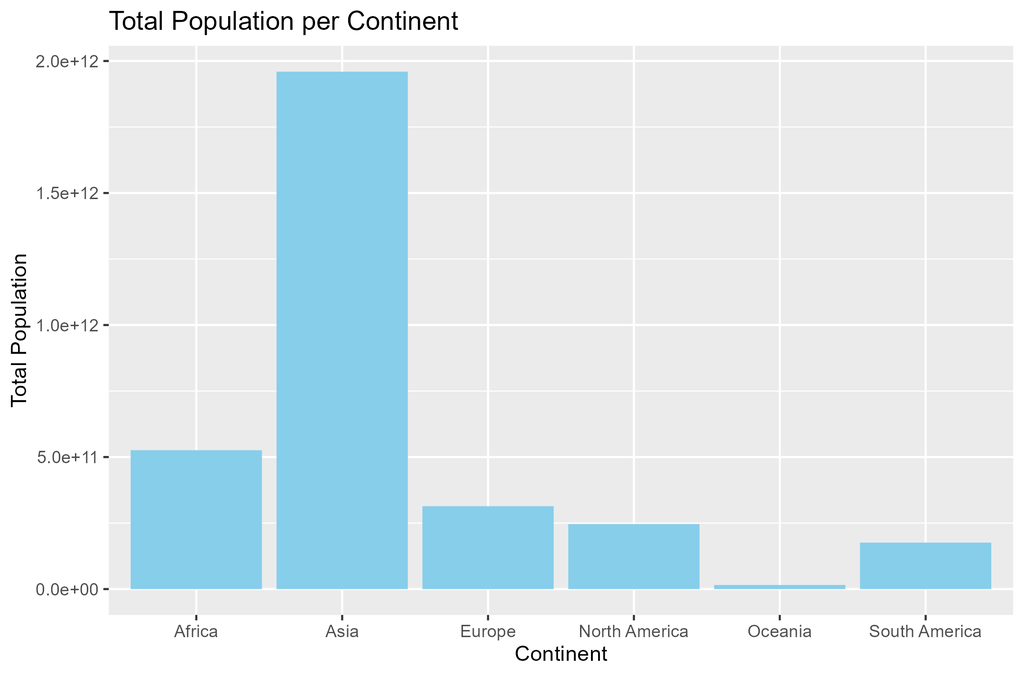

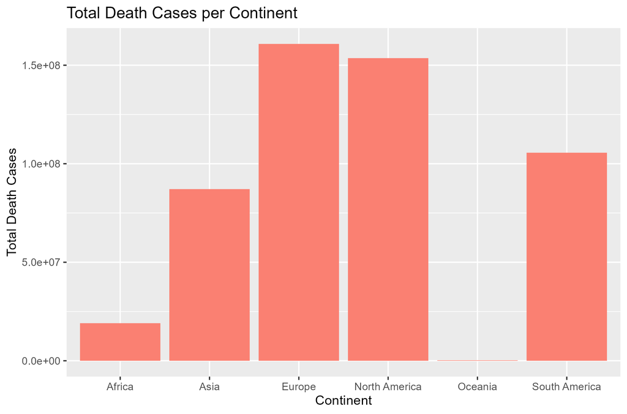

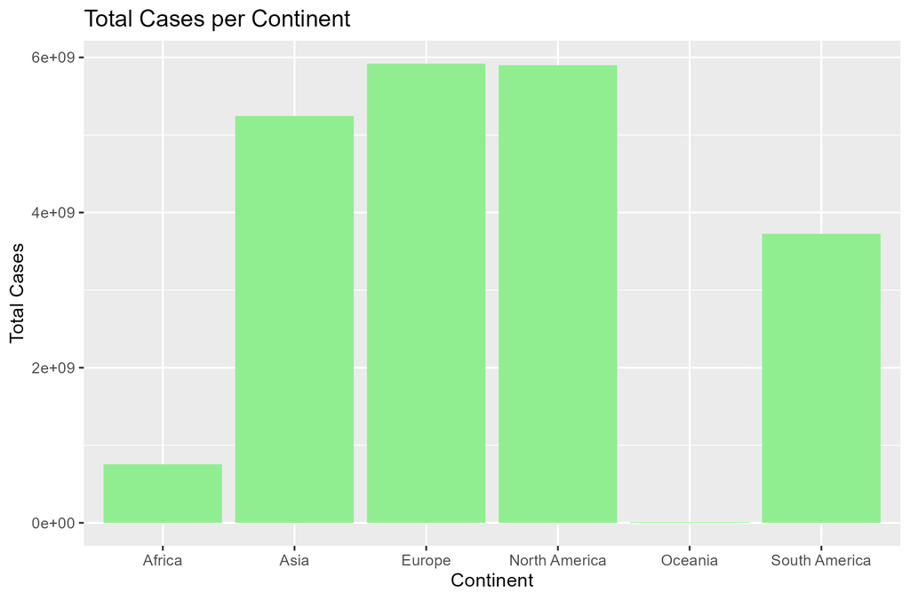

## Conclusion

This analysis provides insights into the distribution of COVID-19 cases and death cases across different continents, highlighting variations in population, disease burden and death cases. From the statistical analysis, Asia has the largest population and Ocenia with the lowest population among the continents. Europe has the highest record of COVID_19 cases and total death cases. It is the concluded from the analysis that Europe encountered the highest loss of lives and has the highest disease burden of COVID_19.